# PML Project

Giuseppe

06 febbraio 2016

# Executive summary

The goal of this project is to predict the manner in which peolple do the exercises. After loading all the packages we need during our analysis and downloading the datasets, I began exploring data. A lot of variables are plenty of NA values, and I removed them from datasets. Then, I checked the zerovariance predictor, the multicollinearity, and finally I split data into train and validation set.

After building and evaluating some models, I found out that the best one is the Random Forest model, and I used it to predict the cases of our test dataset.

### installing/loading the packages:

### clearing the workspace

```r
rm(list=ls())
```

### importing the data

```r
train_file <- "https://d396qusza40orc.cloudfront.net/predmachlearn/pml-training.csv"
train <- read.csv(url(train_file), na.strings=c("", "NA", "NULL", "#DIV/0!"), stringsAsFactors=TRUE)
test_file <- "https://d396qusza40orc.cloudfront.net/predmachlearn/pml-testing.csv"
test <- read.csv(url(test_file), na.strings=c("", "NA", "NULL", "#DIV/0!"), stringsAsFactors=TRUE)
```

## EDA

```r
dim(train)
```

```
## [1] 19622   160
```

```r
#str(train)
table(train$classe)/nrow(train)
```

```
##
##         A         B         C         D         E
## 0.2843747 0.1935073 0.1743961 0.1638977 0.1838243
```

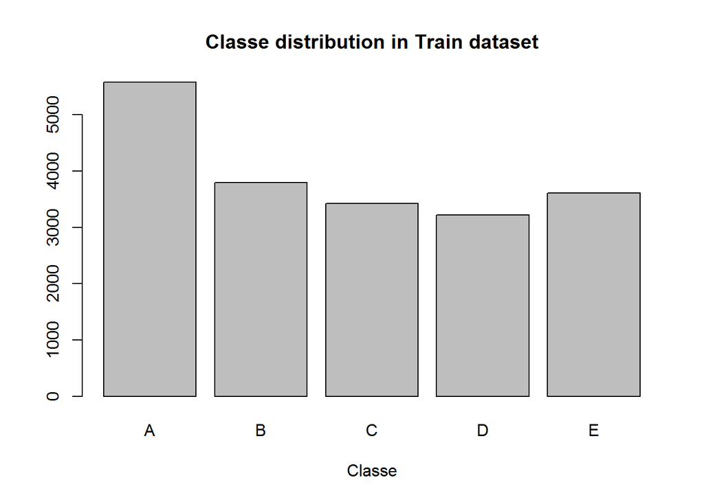

```r
plot(train$classe, main="Classe distribution in Train dataset", xlab="Classe")
```

```r
train_status <- df_status(train)
```

```
##                     variable q_zeros p_zeros  q_na   p_na    type unique
## 1                          X       0    0.00     0   0.00 integer  19622
## 2                  user_name       0    0.00     0   0.00  factor      6
## 3       raw_timestamp_part_1       0    0.00     0   0.00 integer    837
## 4       raw_timestamp_part_2       0    0.00     0   0.00 integer  16783
## 5             cvtd_timestamp       0    0.00     0   0.00  factor     20
## 6                 new_window       0    0.00     0   0.00  factor      2
## 7                 num_window       0    0.00     0   0.00 integer    858
## 8                  roll_belt       5    0.03     0   0.00 numeric   1330
## 9                 pitch_belt       1    0.01     0   0.00 numeric   1840
## 10                  yaw_belt       3    0.02     0   0.00 numeric   1957
## 11          total_accel_belt       3    0.02     0   0.00 integer     29
## 12        kurtosis_roll_belt       0    0.00 19226  97.98 numeric    395
## 13       kurtosis_picth_belt       0    0.00 19248  98.09 numeric    315
## 14         kurtosis_yaw_belt       0    0.00 19622 100.00 logical      0
```

[output cut: 146 more lines]

```r
#q_zeros: quantity of zeros (p_zeros: in percentage)
#q_na: quantity of NA (p_na: in percentage)
#type: factor or numeric
#unique: quantity of unique values
```

# Data Preparation

## Removing variables with at least 75% of NA values

```r
vars_to_remove=subset(train_status, train_status$p_na > 75)
vars_to_remove["variable"]
```

```
##                     variable
## 12        kurtosis_roll_belt
## 13       kurtosis_picth_belt
## 14         kurtosis_yaw_belt
## 15        skewness_roll_belt
## 16      skewness_roll_belt.1
## 17         skewness_yaw_belt
## 18             max_roll_belt
## 19            max_picth_belt
## 20              max_yaw_belt
## 21             min_roll_belt
## 22            min_pitch_belt
## 23              min_yaw_belt
## 24       amplitude_roll_belt
## 25      amplitude_pitch_belt
```

[output cut: 86 more lines]

```r
## Keeping all except vars_to_remove
train=train[, !(names(train) %in% vars_to_remove[,"variable"])]
test=test[, !(names(test) %in% vars_to_remove[,"variable"])]
```

## Removing other columns that are not important for the analysis

```r
train <- train[, -c(1:7)]
test <- test[, -c(1:7)]
dim(train); dim(test)
```

```
## [1] 19622    53
```

```
## [1] 20 53
```

## Transforming all integer to numeric variables

```r
train[, c(4,8:13,17,21:26,30,34:38,43,47:50)]  <- as.numeric(unlist(train[, c(4,8:13,17,21:26,30,34:38,43,47:50)]))
test[, c(4,8:13,17,21:26,30,34:38,43,47:50)]  <- as.numeric(unlist(test[, c(4,8:13,17,21:26,30,34:38,43,47:50)]))
```

## Filtering Predictors

### Checking for multicollinearity

Since a lot of models can have poor performance in case of multicollinearity (i.e., high correlations between predictors) I now evaluate if this is the case. Principal component analysis can be used to reduce the number of dimensions or, alternatively, I can identify and remove predictors that contribute the most to the correlations. In this project I decided to remove all predictors with correlations greater than 0.90 (using the findCorrelation function).

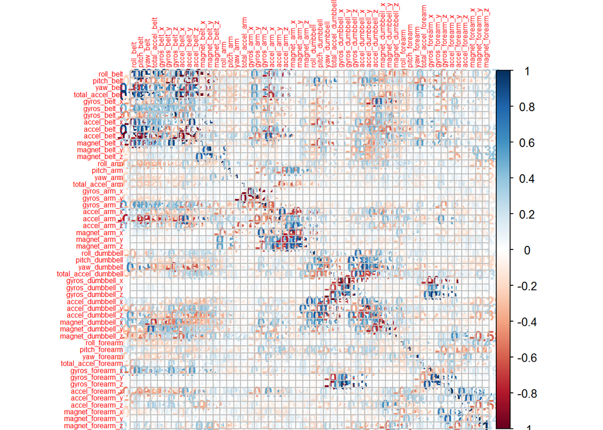

```r
corrplot(cor(train[, -53]), method = "number", tl.cex = 0.5)
```

```r
ncol(train)
```

```
## [1] 53
```

```r
trainCorr <- cor(train[-53])
highCorr <- findCorrelation(trainCorr, 0.90)
train <- train[, -highCorr]
test <- test[, -highCorr]
ncol(train); ncol(test)
```

```
## [1] 46
```

```
## [1] 46
```

### Checking for zerovariance predictors

Another problem could be the presence of “zerovariance predictors” that will cause the model to fail. The function nearZeroVar can be used to identify near zero-variance predictors in a dataset.

```r
nzv <- nearZeroVar(train, saveMetrics= TRUE)
head (nzv)
```

```
##                  freqRatio percentUnique zeroVar   nzv
## pitch_belt        1.036082     9.3772296   FALSE FALSE
## yaw_belt          1.058480     9.9734991   FALSE FALSE
## total_accel_belt  1.063160     0.1477933   FALSE FALSE
## gyros_belt_x      1.058651     0.7134849   FALSE FALSE
## gyros_belt_y      1.144000     0.3516461   FALSE FALSE
## gyros_belt_z      1.066214     0.8612782   FALSE FALSE
```

```r
nzv[nzv$nzv,][1:10,]
```

```
##      freqRatio percentUnique zeroVar nzv
## NA          NA            NA      NA  NA
## NA.1        NA            NA      NA  NA
## NA.2        NA            NA      NA  NA
## NA.3        NA            NA      NA  NA
## NA.4        NA            NA      NA  NA
## NA.5        NA            NA      NA  NA
## NA.6        NA            NA      NA  NA
## NA.7        NA            NA      NA  NA
## NA.8        NA            NA      NA  NA
## NA.9        NA            NA      NA  NA
```

```r
dim(train)
```

```
## [1] 19622    46
```

```r
nzv <- nearZeroVar(train)
#filteredDescr <- train[, -nzv]

# there are no "zerovariance predictors"

#dim(train)
```

## Splitting data in train and validation set

I’m going to do an initial split of the data into train and vaidation sets. The validation set will be used only to evaluate performance and the train set will be used to build models. 70% of the data will be used for training model and the remaining will be used for evaluating model performance.

```r
set.seed(131292)
# Initial data split
inTrain <- createDataPartition(train$classe, p = 0.7, list = FALSE)
trainSet <- train[inTrain, ]
validationSet <- train[-inTrain, ]
dim(trainSet); dim(validationSet)
```

```
## [1] 13737    46
```

```
## [1] 5885   46
```

# Train Model

```r
# I set up R for parallel processing with the following code, which will allow caret to allot tasks to 4 cores simultaneously
registerDoSNOW(makeCluster(4, type = "SOCK"))
```

## Tuning and Building models

```r
# Setting the parameters for model preprocessing and tuning from the caret package:
cvControl <- trainControl(## 10-fold Crossvalidation
                           method = "repeatedcv",
                           repeats = 3,
                           number=10,
                           # PCA Preprocessing
                           preProcOptions="pca"
                           )

# Model Training
set.seed(131292)
model.rpart <- train(classe ~ ., data=trainSet, method="rpart", cp=0.1, trControl= cvControl)
set.seed(131292)
model.rf <- train(classe ~ ., data = trainSet, method = "rf", trControl= cvControl)
set.seed(131292)
model.gbm <- train(classe ~ ., data = trainSet, method = "gbm", trControl= cvControl)
set.seed(131292)
model.svmRadial <- train(classe ~ ., data = trainSet, method = "svmRadial", tuneLength = 5, trControl = cvControl)
set.seed(131292)
model.svmLinear <- train(classe ~ ., data = trainSet, method = "svmLinear", tuneLength = 5, trControl = cvControl)
```

## Evaluating Model Performances

```r
# Collect resamples
models <- list(rpart = model.rpart, rf = model.rf, gbm = model.gbm, svmRadial = model.svmRadial, svmLinear = model.svmLinear)
cvValues <- resamples(models)
summary(cvValues)
```

```
##
## Call:
## summary.resamples(object = cvValues)
##
## Models: rpart, rf, gbm, svmRadial, svmLinear
## Number of resamples: 30
##
## Accuracy
##             Min. 1st Qu. Median   Mean 3rd Qu.   Max. NA's
## rpart     0.4810  0.4977 0.5073 0.5083  0.5195 0.5470    0
## rf        0.9883  0.9905 0.9927 0.9925  0.9942 0.9971    0
## gbm       0.9476  0.9534 0.9571 0.9571  0.9605 0.9651    0
## svmRadial 0.9534  0.9607 0.9632 0.9639  0.9663 0.9738    0
## svmLinear 0.7298  0.7458 0.7530 0.7516  0.7569 0.7649    0
##
## Kappa
##             Min. 1st Qu. Median   Mean 3rd Qu.   Max. NA's
## rpart     0.3212  0.3464 0.3639 0.3630  0.3753 0.4315    0
## rf        0.9853  0.9880 0.9908 0.9905  0.9926 0.9963    0
## gbm       0.9338  0.9411 0.9457 0.9457  0.9500 0.9558    0
## svmRadial 0.9410  0.9502 0.9534 0.9543  0.9574 0.9668    0
## svmLinear 0.6561  0.6766 0.6854 0.6840  0.6906 0.7018    0
```

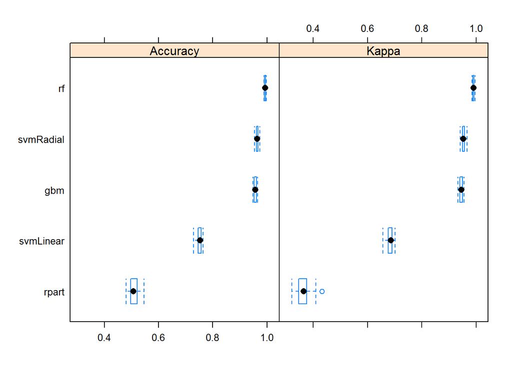

```r
bwplot(cvValues)
```

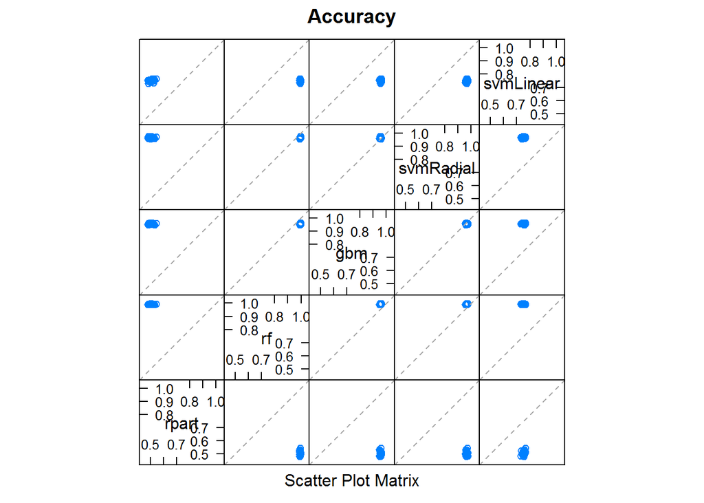

```r
#dotplot(cvValues)
#parallelplot(cvValues)
#xyplot(cvValues)
splom(cvValues)
```

```r
summary(diff(cvValues))
```

```
##
## Call:
## summary.diff.resamples(object = diff(cvValues))
##
## p-value adjustment: bonferroni
## Upper diagonal: estimates of the difference
## Lower diagonal: p-value for H0: difference = 0
##
## Accuracy
##           rpart   rf        gbm       svmRadial svmLinear
## rpart             -0.484141 -0.448811 -0.455605 -0.243333
## rf        < 2e-16            0.035330  0.028536  0.240807
## gbm       < 2e-16 < 2e-16             -0.006794  0.205478
## svmRadial < 2e-16 < 2e-16   2.1e-05              0.212272
## svmLinear < 2e-16 < 2e-16   < 2e-16   < 2e-16
##
## Kappa
##           rpart     rf        gbm       svmRadial svmLinear
## rpart               -0.627500 -0.582795 -0.591353 -0.321081
## rf        < 2.2e-16            0.044705  0.036147  0.306419
## gbm       < 2.2e-16 < 2.2e-16           -0.008558  0.261714
## svmRadial < 2.2e-16 < 2.2e-16 2.296e-05            0.270272
## svmLinear < 2.2e-16 < 2.2e-16 < 2.2e-16 < 2.2e-16
```

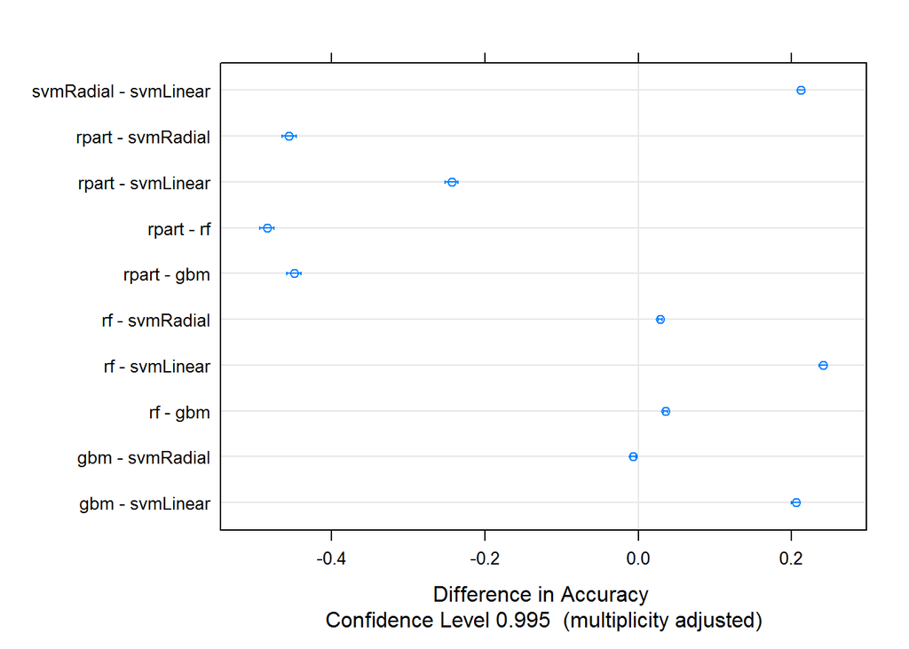

```r
dotplot(diff(cvValues))
```

```r
print(models)
```

```
## $rpart
## CART
##
## 13737 samples
##    45 predictor
##     5 classes: 'A', 'B', 'C', 'D', 'E'
##
## No pre-processing
## Resampling: Cross-Validated (10 fold, repeated 3 times)
## Summary of sample sizes: 12364, 12363, 12364, 12364, 12362, 12364, ...
## Resampling results across tuning parameters:
##
##   cp          Accuracy   Kappa      Accuracy SD  Kappa SD
##   0.02868477  0.5083122  0.3629533  0.01587351   0.02586131
##   0.03295697  0.4861069  0.3330274  0.02094466   0.03541234
##   0.06619367  0.3939700  0.1818031  0.09120650   0.15109939
##
## Accuracy was used to select the optimal model using  the largest value.
## The final value used for the model was cp = 0.02868477.
##
## $rf
## Random Forest
##
## 13737 samples
##    45 predictor
##     5 classes: 'A', 'B', 'C', 'D', 'E'
##
## No pre-processing
## Resampling: Cross-Validated (10 fold, repeated 3 times)
## Summary of sample sizes: 12364, 12363, 12364, 12364, 12362, 12364, ...
## Resampling results across tuning parameters:
##
##   mtry  Accuracy   Kappa      Accuracy SD  Kappa SD
##    2    0.9915551  0.9893163  0.002235986  0.002829609
##   23    0.9924529  0.9904530  0.002453570  0.003104022
##   45    0.9867747  0.9832688  0.004486934  0.005676982
##
## Accuracy was used to select the optimal model using  the largest value.
## The final value used for the model was mtry = 23.
##
```

[output cut: 65 more lines]

```
##
## 13737 samples
##    45 predictor
##     5 classes: 'A', 'B', 'C', 'D', 'E'
##
## No pre-processing
## Resampling: Cross-Validated (10 fold, repeated 3 times)
## Summary of sample sizes: 12364, 12363, 12364, 12364, 12362, 12364, ...
## Resampling results
##
##   Accuracy   Kappa     Accuracy SD  Kappa SD
##   0.7516454  0.684034  0.00875062   0.01112086
##
## Tuning parameter 'C' was held constant at a value of 1
##
```

```r
model.rf$finalModel
```

```
##
## Call:
##  randomForest(x = x, y = y, mtry = param$mtry)
##                Type of random forest: classification
##                      Number of trees: 500
## No. of variables tried at each split: 23
##
##         OOB estimate of  error rate: 0.66%
## Confusion matrix:
##      A    B    C    D    E class.error
## A 3901    5    0    0    0 0.001280082
## B   18 2631    8    0    1 0.010158014
## C    0   14 2373    9    0 0.009599332
## D    0    0   21 2228    3 0.010657194
## E    0    0    6    5 2514 0.004356436
```

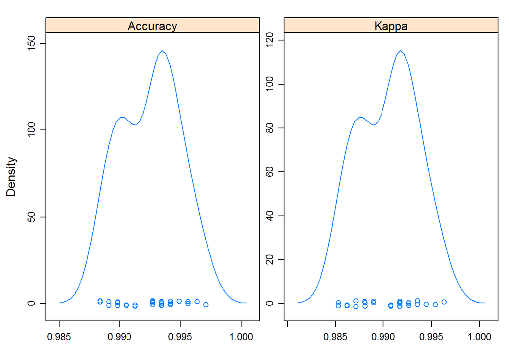

```r
#Density plots
resampleHist(model.rf)
```

### I can consider the Random Forest the best model in the list, and so I explore it more in detail and then we use it on validation and test datasets.

## Predictor importance

```r
varImp(model.rf, scale = FALSE)
```

```
## rf variable importance
##
##   only 20 most important variables shown (out of 45)
##
##                      Overall
## yaw_belt              1104.9
## pitch_forearm          944.7
## pitch_belt             765.1
## magnet_dumbbell_z      740.1
## magnet_dumbbell_y      617.9
## roll_forearm           525.9
## magnet_belt_y          478.6
## magnet_belt_z          365.4
## gyros_belt_z           353.6
## accel_dumbbell_y       307.3
## roll_dumbbell          301.8
## magnet_dumbbell_x      292.1
## accel_forearm_x        254.5
## accel_forearm_z        234.9
## total_accel_belt       225.3
## accel_dumbbell_z       220.9
## total_accel_dumbbell   220.2
## magnet_forearm_z       205.6
## magnet_belt_x          204.6
## roll_arm               183.3
```

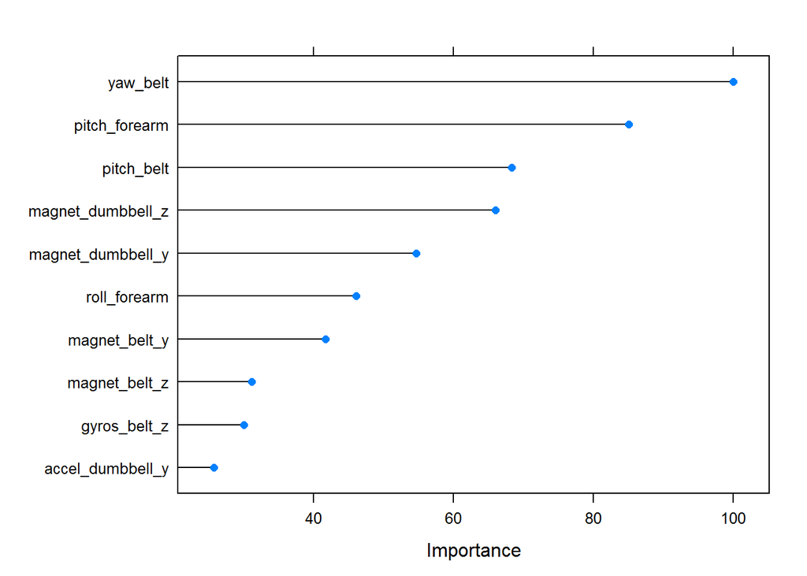

```r
plot(varImp(model.rf), top = 10)
```

## Model Evaluation

```r
valid.prediction <- predict(model.rf, validationSet)
confusionMatrix(valid.prediction,validationSet$classe)
```

```
## Confusion Matrix and Statistics
##
##           Reference
## Prediction    A    B    C    D    E
##          A 1670    7    0    0    0
##          B    2 1130    3    0    0
##          C    1    2 1022    9    1
##          D    0    0    1  954    2
##          E    1    0    0    1 1079
##
## Overall Statistics
##
##                Accuracy : 0.9949
##                  95% CI : (0.9927, 0.9966)
##     No Information Rate : 0.2845
##     P-Value [Acc > NIR] : < 2.2e-16
##
##                   Kappa : 0.9936
##  Mcnemar's Test P-Value : NA
##
## Statistics by Class:
##
##                      Class: A Class: B Class: C Class: D Class: E
## Sensitivity            0.9976   0.9921   0.9961   0.9896   0.9972
## Specificity            0.9983   0.9989   0.9973   0.9994   0.9996
## Pos Pred Value         0.9958   0.9956   0.9874   0.9969   0.9981
## Neg Pred Value         0.9990   0.9981   0.9992   0.9980   0.9994
## Prevalence             0.2845   0.1935   0.1743   0.1638   0.1839
## Detection Rate         0.2838   0.1920   0.1737   0.1621   0.1833
## Detection Prevalence   0.2850   0.1929   0.1759   0.1626   0.1837
## Balanced Accuracy      0.9980   0.9955   0.9967   0.9945   0.9984
```

### To finish the project I use our model to predict our 20 test cases.

```r
test.prediction <- predict(model.rf,test)
test.prediction
```

```
##  [1] B A B A A E D B A A B C B A E E A B B B
## Levels: A B C D E
```

```r
# all quiz questions were answered correctly
```

## Reference

Journal of Statistical Software November 2008, Volume 28, Issue 5. http://www.jstatsoft.org/

Package ‘caret’ January 6, 2016 Version 6.0-64 Date 2016-01-04